# IODS-final

## Visualization

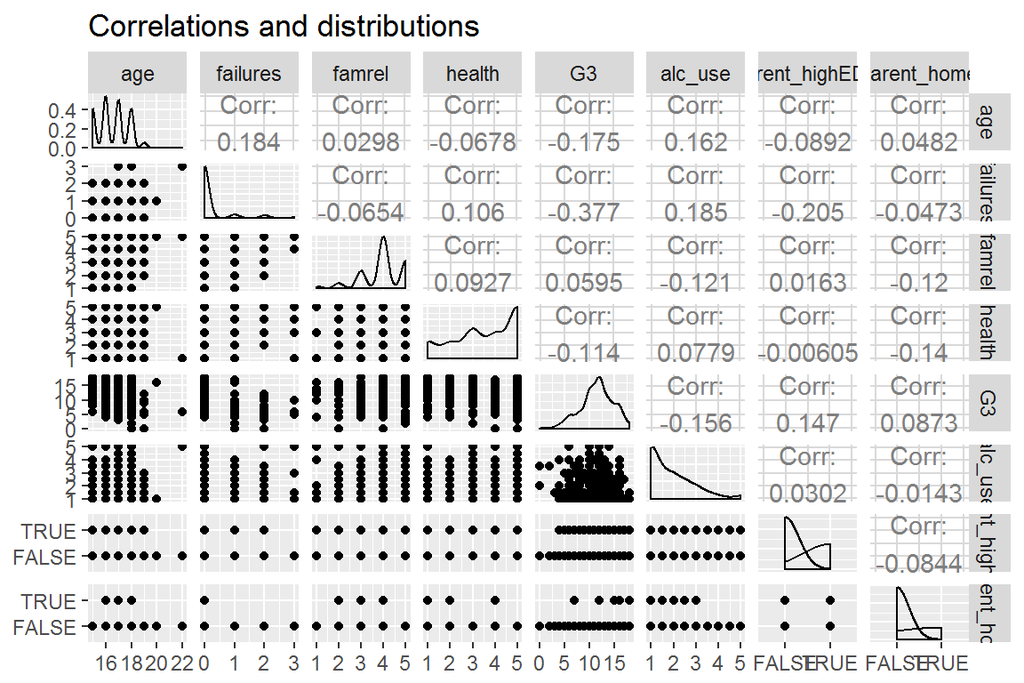

```r
# Selecting the variables that relate to our research question
variables <- c("age", "failures", "famrel","health","G3","alc_use","parent_highEDU", "parent_home")

alc2 <- select(alc, one_of(variables))
ggpairs(alc2) + ggtitle("Correlations and distributions")
```

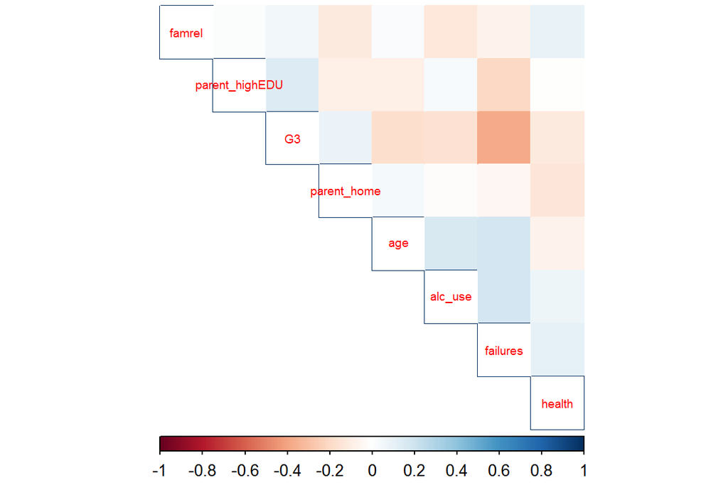

```r
corrplot(cor(alc2), method = "color" ,type="upper", cl.pos="b", tl.pos="d",tl.cex=0.6, order = "AOE")
```

Above you can see distributions and correlations. First plot is plotted by command “ggplot”. The scatter plots (lower left) and distributions (diagonal) are a bit messy because there are many logical variables and the other variables can only get certain discrete values. The second plot is only the correlations. As you can see there is a strong negative correlation between the final grade and failures. This is not surprising. One of the highest positive correlations can be seen in the correlation between parents education and grades.

## My method of choice

I chose linear regression as my method of analysis. Linear regression is a basic way to examine if a set of predictor variables do a good job in predicting the outcome and which variables are good predictors of the dependent variable. When only one variable is used as a explanatory variable, it is called simple linear regression. When there is more than just one explanatory variable, it is called multiple linear regression.